# Analysis of expression of Transposable Elements in Lsh-/- and wt B cells

Sara Formichetti

EMBL Rome  
sara.formichetti@embl.it

November 11, 2020

# 1 Reading the data

The input files are:

- the output tables made by featureCounts (run in rule 'count_on_TE' of the Snakefile), which contain read counts of all repetitive elements (i.e. all repNames) for all samples
- the repetitive elements annotation ../../data/annotations/RepeatMasker_RepeatLibrary20140131_mm10.noGenes.noSimple.bed (converted to SAF format in rule of Snakefile) used for featureCounts command, that is used to retrieve repFamily and repClass for each repName. The annotation I chose is the most updated library (to date) of rmsk, from which I removed 'Simple repeats' and 'Low complexity regions'
- a table with total number of reads per sample in raw fastq files
- the samples' table, containing infos on experimental design:

Samples table

| SRR | sample | condition | group_or_time_point | biol_rep | tech_rep | run | library_layout | read_length |
| --- | --- | --- | --- | --- | --- | --- | --- | --- |
| none | naives_345 | WT | 1 | 1 | 1 | 1 | PAIRED - | 101 |
| none | naives_266 | WT | 1 | 2 | 1 | 1 | PAIRED - | 101 |
| none | naives_344 | WT | 1 | 3 | 1 | 1 | PAIRED - | 101 |
| none | naives_325 | WT | 1 | 4 | 1 | 1 | PAIRED - | 101 |
| none | naives_440 | KO | 1 | 1 | 1 | 1 | PAIRED - | 101 |
| none | naives_278 | KO | 1 | 2 | 1 | 1 | PAIRED - | 101 |
| none | naives_287 | KO | 1 | 3 | 1 | 1 | PAIRED - | 101 |
| none | naives_340 | KO | 1 | 4 | 1 | 1 | PAIRED - | 101 |
| none | J7_300 | WT | 2 | 1 | 1 | 1 | PAIRED - | 101 |
| none | J7_305 | WT | 2 | 2 | 1 | 1 | PAIRED - | 101 |
| none | J7_189 | WT | 2 | 3 | 1 | 1 | PAIRED - | 101 |
| none | J7_290 | WT | 2 | 4 | 1 | 1 | PAIRED - | 101 |
| none | J7_400 | KO | 2 | 1 | 1 | 1 | PAIRED - | 101 |
| none | J7_187 | KO | 2 | 2 | 1 | 1 | PAIRED - | 101 |
| none | J7_291 | KO | 2 | 3 | 1 | 1 | PAIRED - | 101 |
| none | J7_399 | KO | 2 | 4 | 1 | 1 | PAIRED - | 101 |
| none | J14_193 | WT | 3 | 1 | 1 | 1 | PAIRED - | 101 |
| none | J14_307 | WT | 3 | 2 | 1 | 1 | PAIRED - | 101 |
| none | J14_350 | WT | 3 | 3 | 1 | 1 | PAIRED - | 101 |
| none | J14_295 | WT | 3 | 4 | 1 | 1 | PAIRED - | 101 |
| none | J14_351 | KO | 3 | 1 | 1 | 1 | PAIRED - | 101 |
| none | J14_186 | KO | 3 | 2 | 1 | 1 | PAIRED - | 101 |
| none | J14_192 | KO | 3 | 3 | 1 | 1 | PAIRED - | 101 |
| none | J14_394 | KO | 3 | 4 | 1 | 1 | PAIRED - | 101 |

# 2 Analysis at family level

## 2.1 FPKM for each family of Repetitive Elements

For each family of Repetitive Elements (in case of elements with no repFamily name or repFamilies belonging to more than one repClass I use repClass) I compute **FPKM** values, as follows: for each sample:

- I compute the sum of counts for all elements belonging to that repFamily
- I divide this sum by the total number of reads sequenced for that sample and multiply by 10⁶
- I divide this number by the total sum of lengths (in Kb) of the elements belonging to that repFamily --> FPKM
- *I subtract from each FPKM the total FPKM of all transposons belonging to the DNA repClass*

## 2.2 Heatmaps

The heatmaps are scaled by rows.

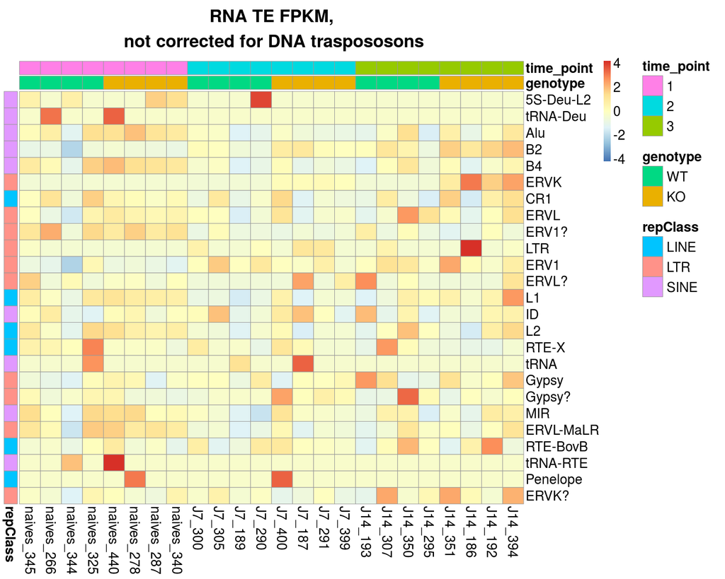

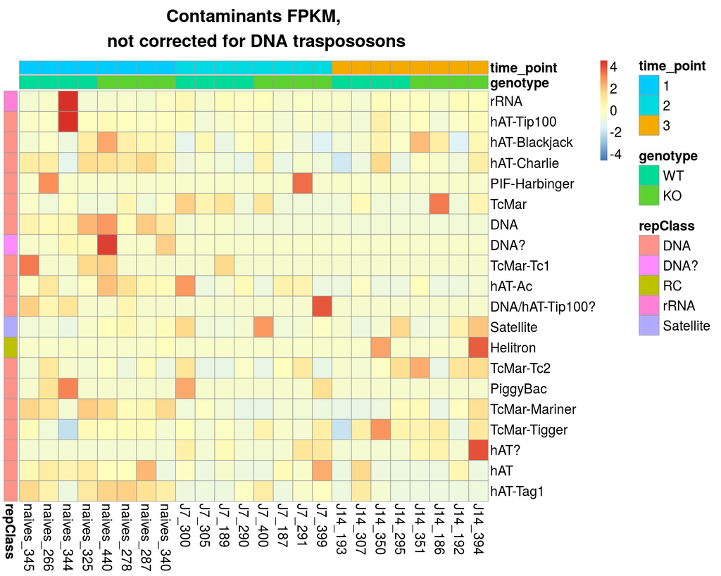

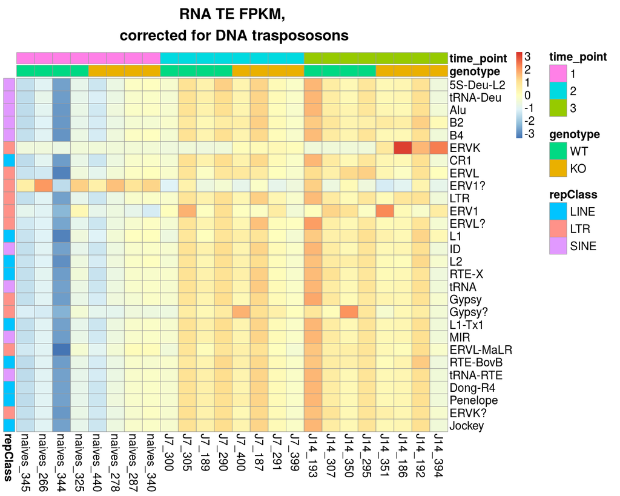

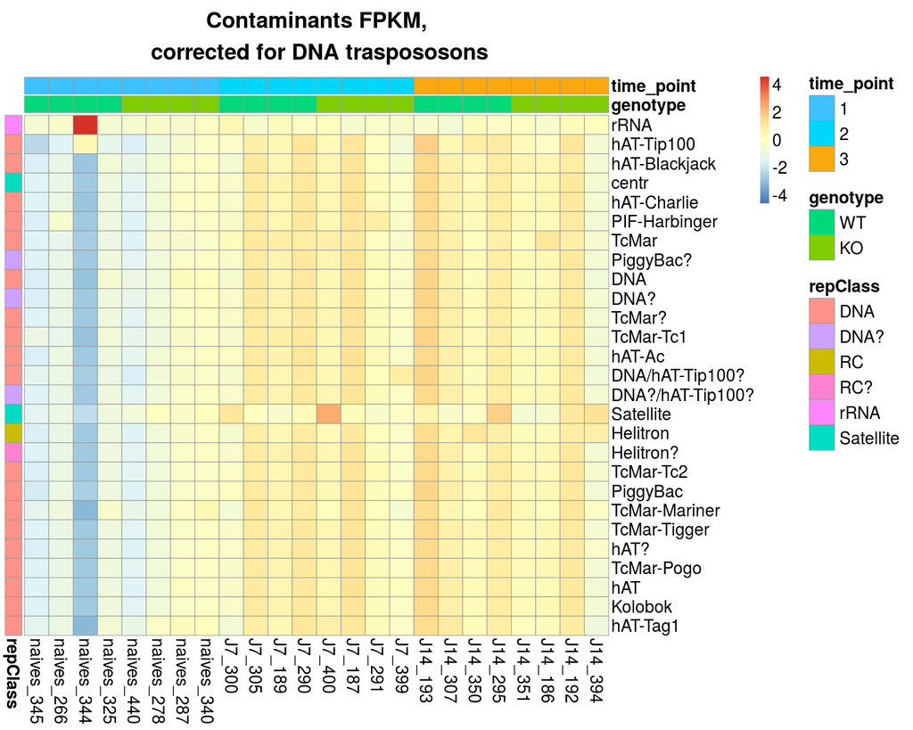

# 3 DE-Seq analysis of RNA transposons

I include the FPKM of DNA transposons as confounding factor in DESeq2 formula.

Before running the Differential Expression analysis, the data are pre-filtered to remove all repetitive elements with < 10 reads among all samples.

## 3.1 MA-plots

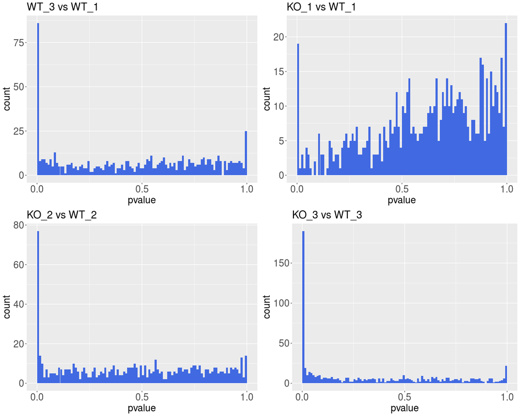

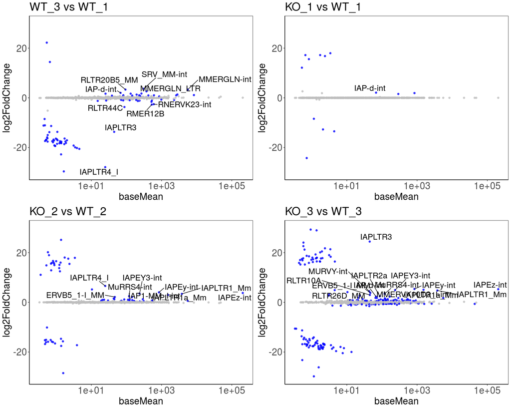

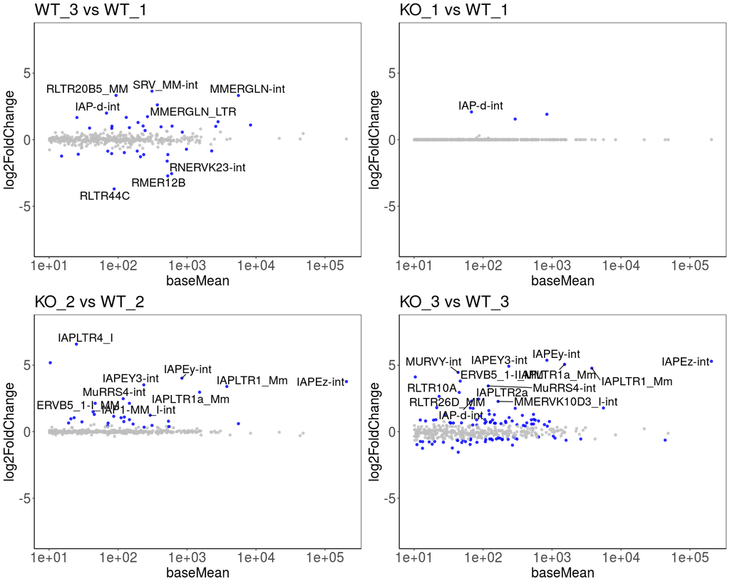

I plot the raw counts for the significantly differentially expressed TE with mean expression > 20 in order to check the variation between replicates:

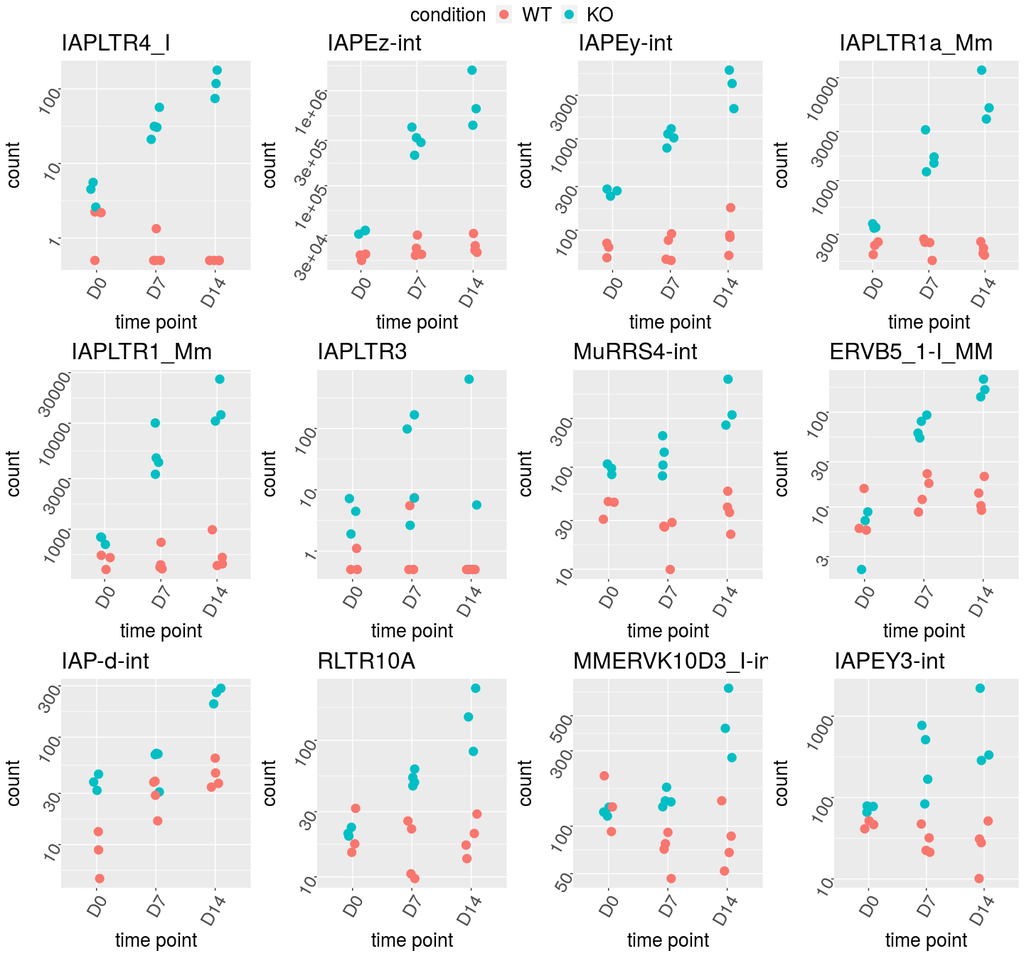

# 4 Better look at full length elements

I consider the following as full-length RNA transposons:

- LINE1 >5kb
- IAP >6kb
- MMERVK10C >4.5kb

In rule 'count_on_TE' of the Snakefile, I also run the featureCounts command only for the annotated TE fulfilling the above requirements.

# 5 Correlation between expression and methylation for full length TE

Before running the Differential Expression analysis, the data are pre-filtered to remove all repetitive elements with < 10 reads among all samples.

For the following methylation-expression plot, only elements with a baseMean >20 are shown, because the very lowly expressed ones would look deregulated just because of noise affecting their small expression values.

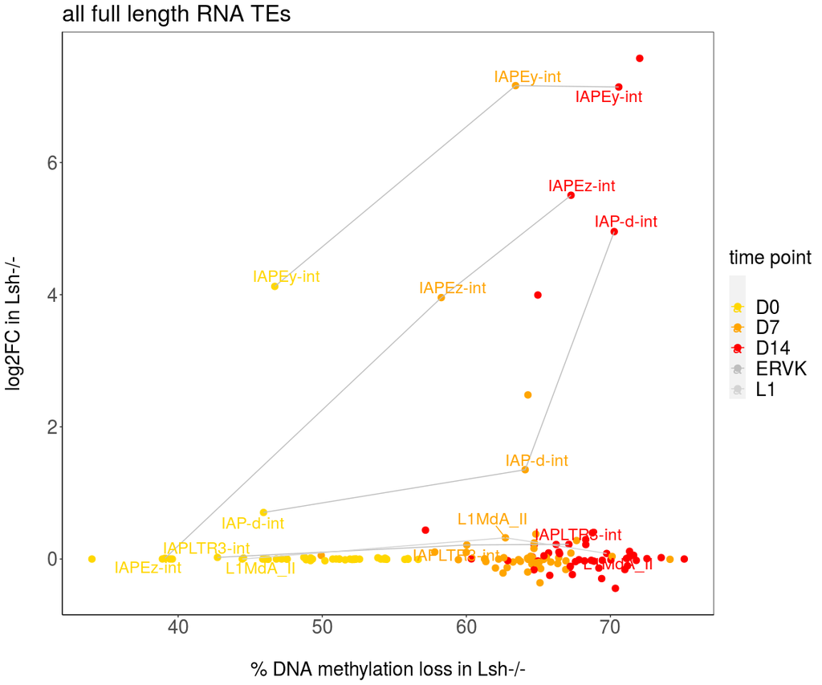